# House Prices Prediction Using Linear Regression

**Sajna Subhagan**

# Index

- Abstract
- 1. Introduction
- 2. The Data
  - 2.1 Import the Data
  - 2.2 Data Exploration
  - 2.3 Data Preparation
  - 2.4 Correlation
- 3. Project Description
  - 3.1 Linear Regression
  - 3.2 Analysis
  - 3.3 Results
  - 3.4 Verify Your Model Against Test Data
- Conclusion
- References

Back to top

Back to top

## 1. Introduction

The objective is to analyze the existing house sale prices data and to **build a model for predicting the house sale prices.** Steps Involved: Importing the dataset followed by exploratory data analysis to find insights into the data.The dataset had 100 rows and 82 columns. **Check for duplicates, nulls** and analyze the data to find patterns and correlations between the dependent & independent variables. Data Preparation involves treating the nulls, converting the categorical columns to numerical or one hot encoding. **Reshaping the data** frame by choosing the relevant independent varaibales based on the correlation coefficients. Log transformation was done on the target variable to get a normal distribution. The algorithm used for predicting the house prices is **Linear Regression.** Linear Regression is a **supervised machine learning algorithm** which performs a regression task. Regression models a target prediction value based on independent variables. 6 Models were developed with various combinations of the independent variables. The independent variables or features were chosen based on their strong correlation with the target variable - Sale price. **The independent variables that exhibited strong correlation to one another were eliminated to avoid multicolliearity**.Multicollinearity is the occurrence of high intercorrelations among two or more independent variables in a multiple regression model. Multicollinearity can lead to skewed or misleading results when trying to determine how well each independent variable can be used most effectively to predict or understand the dependent variable in a statistical model. The best model was chosen based on the **R- squared scores** which determines the proportion of variance in the dependent variable that can be explained by the independent variable.The Rsquared scores were **0.89 for the training dataset** and **0.86 for the testing dataset** and uses 17 features/independent variables.

Back to top

## 2. The Data

### Data Description

The Housesmall Data consists of 100 records and 82 variables and has the following information

**SalePrice** : Saleprice of the house

**MSSubClass**: Identifies the type of dwelling involved in the sale  
**MSZoning**: Identifies the general zoning classification of the sale.

**LotFrontage**: Linear feet of street connected to property

**LotArea**: Lot size in square feet

**Street**: Type of road access to property

**Alley**: Type of alley access to property

**LotShape**: General shape of property

**LandContour**: Flatness of the property

**Utilities**: Type of utilities available

**LotConfig**: Lot configuration

**LandSlope**: Slope of property

**Neighborhood**: Physical locations within Ames city limits

**Condition1**: Proximity to various conditions

**Condition2**: Proximity to various conditions (if more than one is present) **BldgType**: Type of dwelling

**HouseStyle**: Style of dwelling

**OverallQual**: Rates the overall material and finish of the house

**OverallCond**: Rates the overall condition of the house

**YearBuilt**: Original construction date

**YearRemodAdd**: Remodel date (same as construction date if no remodeling or additions)

**RoofStyle**: Type of roof

**RoofMatl**: Roof material

**Exterior1st**: Exterior covering on house

**Exterior2nd**: Exterior covering on house (if more than one material)

**MasVnrType**: Masonry veneer type

**MasVnrArea**: Masonry veneer area in square feet

**ExterQual**: Evaluates the quality of the material on the exterior

**ExterCond**: Evaluates the present condition of the material on the exterior

**Foundation**: Type of foundation

**BsmtQual**: Evaluates the height of the basement

**BsmtCond**: Evaluates the general condition of the basement

**BsmtExposure**: Refers to walkout or garden level walls

**BsmtFinType1**: Rating of basement finished area

**BsmtFinSF1**: Type 1 finished square feet

**BsmtFinType2**: Rating of basement finished area (if multiple types)

**BsmtFinSF2**: Type 2 finished square feet

**BsmtUnfSF**: Unfinished square feet of basement area

**TotalBsmtSF**: Total square feet of basement area

**Heating**: Type of heating

**HeatingQC**: Heating quality and condition

**CentralAir**: Central air conditioning

**Electrical**: Electrical system

**1stFlrSF**: First Floor square feet

**2ndFlrSF**: Second floor square feet

**LowQualFinSF**: Low quality finished square feet (all floors)

**GrLivArea**: Above grade (ground) living area square feet

**BsmtFullBath**: Basement full bathrooms

**BsmtHalfBath**: Basement half bathrooms

**FullBath**: Full bathrooms above grade

**HalfBath**: Half baths above grade

**Bedroom**: Bedrooms above grade (does NOT include basement bedrooms)

**Kitchen**: Kitchens above grade

**KitchenQual**: Kitchen quality

**TotRmsAbvGrd**: Total rooms above grade (does not include bathrooms)

**Functional**: Home functionality (Assume typical unless deductions are warranted)

**Fireplaces**: Number of fireplaces

**FireplaceQu**: Fireplace quality

**GarageType**: Garage location

**GarageYrBlt**: Year garage was built

**GarageFinish**: Interior finish of the garage

**GarageCars**: Size of garage in car capacity

**GarageArea**: Size of garage in square feet

**GarageQual**: Garage quality

**GarageCond**: Garage condition

**PavedDrive**: Paved driveway

**WoodDeckSF**: Wood deck area in square feet

**OpenPorchSF**: Open porch area in square feet

**EnclosedPorch**: Enclosed porch area in square feet

**3SsnPorch**: Three season porch area in square feet

**ScreenPorch**: Screen porch area in square feet

**PoolArea**: Pool area in square feet

**PoolQC**: Pool quality

**Fence**: Fence quality

**MiscFeature**: Miscellaneous feature not covered in other categories

**MiscVal**: $Value of miscellaneous feature

**MoSold**: Month Sold (MM)

**YrSold**: Year Sold (YYYY)

**SaleType**: Type of sale

**SaleCondition**: Condition of sale

Back to top

### 2.1 Import the Data

```python
#Import the necessary libraries

import pandas as pd # Library for array computing

import numpy as np #Library for array computing

import matplotlib.pyplot as plt # Library for plots and visualisation

import seaborn as sns # library for visualisations

from sklearn import linear_model # importing linear_model from sklearn (library for machine learning, pre-processing, cross-validation and visualisation techniques)

import warnings #To suppress warnings
warnings.filterwarnings('ignore')
```

```python
# Import the data
hsd = pd.read_csv('houseSmallData.csv')

# Create a copy of the imported data
data = hsd.copy()

# Check the shape of the data
data.shape
```

```
(100, 82)
```

**The data has 100 rows and 82 columns**

```python
#Checking the top 5 records
data.head()
```

|  | Unnamed: 0 | Id | MSSubClass | MSZoning | LotFrontage | LotArea | Street | Alley | LotShape | LandContour | ... | PoolArea | PoolQC | Fence | MiscFeature | MiscVal | MoSold | YrSold | SaleType | SaleCondition | SalePrice |
| --- | --- | --- | --- | --- | --- | --- | --- | --- | --- | --- | --- | --- | --- | --- | --- | --- | --- | --- | --- | --- | --- |
| 0 | 0 | 1 | 60 | RL | 65.0 | 8450 | Pave | NaN | Reg | Lvl | ... | 0 | NaN | NaN | NaN | 0 | 2 | 2008 | WD | Normal | 208500 |
| 1 | 1 | 2 | 20 | RL | 80.0 | 9600 | Pave | NaN | Reg | Lvl | ... | 0 | NaN | NaN | NaN | 0 | 5 | 2007 | WD | Normal | 181500 |
| 2 | 2 | 3 | 60 | RL | 68.0 | 11250 | Pave | NaN | IR1 | Lvl | ... | 0 | NaN | NaN | NaN | 0 | 9 | 2008 | WD | Normal | 223500 |
| 3 | 3 | 4 | 70 | RL | 60.0 | 9550 | Pave | NaN | IR1 | Lvl | ... | 0 | NaN | NaN | NaN | 0 | 2 | 2006 | WD | Abnorml | 140000 |
| 4 | 4 | 5 | 60 | RL | 84.0 | 14260 | Pave | NaN | IR1 | Lvl | ... | 0 | NaN | NaN | NaN | 0 | 12 | 2008 | WD | Normal | 250000 |

5 rows × 82 columns

Back to top

### 2.2 Data Exploration

```python
data.info()
```

```
<class 'pandas.core.frame.DataFrame'>
RangeIndex: 100 entries, 0 to 99
Data columns (total 82 columns):
 #   Column         Non-Null Count  Dtype
---  ------         --------------  -----
 0   Unnamed: 0     100 non-null    int64
 1   Id             100 non-null    int64
 2   MSSubClass     100 non-null    int64
 3   MSZoning       100 non-null    object
 4   LotFrontage    86 non-null     float64
 5   LotArea        100 non-null    int64
 6   Street         100 non-null    object
 7   Alley          6 non-null      object
 8   LotShape       100 non-null    object
 9   LandContour    100 non-null    object
```

[output cut: 74 more lines]

**Out of the 82 columns, 36 columns have int64 datatype, 4 columns have float datatype and 42 columns have object datatypes. The data has null values.**

```python
#Summary statistics of the numerical columns
data.describe().T.round(2)
```

|  | count | mean | std | min | 25% | 50% | 75% | max |
| --- | --- | --- | --- | --- | --- | --- | --- | --- |
| Unnamed: 0 | 100.0 | 49.50 | 29.01 | 0.0 | 24.75 | 49.5 | 74.25 | 99.0 |
| Id | 100.0 | 50.50 | 29.01 | 1.0 | 25.75 | 50.5 | 75.25 | 100.0 |
| MSSubClass | 100.0 | 52.00 | 42.55 | 20.0 | 20.00 | 45.0 | 60.00 | 190.0 |
| LotFrontage | 86.0 | 71.41 | 21.09 | 21.0 | 60.00 | 70.0 | 84.00 | 122.0 |
| LotArea | 100.0 | 10115.87 | 5130.54 | 1596.0 | 7643.25 | 9595.5 | 11243.25 | 50271.0 |
| OverallQual | 100.0 | 5.98 | 1.53 | 3.0 | 5.00 | 6.0 | 7.00 | 10.0 |
| OverallCond | 100.0 | 5.50 | 0.98 | 2.0 | 5.00 | 5.0 | 6.00 | 8.0 |
| YearBuilt | 100.0 | 1971.41 | 29.37 | 1910.0 | 1954.75 | 1970.0 | 2000.25 | 2009.0 |
| YearRemodAdd | 100.0 | 1983.92 | 20.97 | 1950.0 | 1964.75 | 1994.0 | 2003.25 | 2009.0 |
| MasVnrArea | 100.0 | 121.64 | 213.55 | 0.0 | 0.00 | 0.0 | 188.50 | 1115.0 |
| BsmtFinSF1 | 100.0 | 454.56 | 462.03 | 0.0 | 0.00 | 416.0 | 737.50 | 1880.0 |
| BsmtFinSF2 | 100.0 | 33.91 | 131.58 | 0.0 | 0.00 | 0.0 | 0.00 | 712.0 |
| BsmtUnfSF | 100.0 | 558.79 | 448.60 | 0.0 | 203.00 | 440.0 | 820.00 | 1777.0 |
| TotalBsmtSF | 100.0 | 1047.26 | 408.50 | 0.0 | 822.00 | 1034.5 | 1268.50 | 2223.0 |
| 1stFlrSF | 100.0 | 1143.53 | 343.40 | 520.0 | 901.50 | 1091.5 | 1325.00 | 2223.0 |
| 2ndFlrSF | 100.0 | 297.21 | 436.05 | 0.0 | 0.00 | 0.0 | 686.00 | 1519.0 |
| LowQualFinSF | 100.0 | 8.73 | 62.37 | 0.0 | 0.00 | 0.0 | 0.00 | 513.0 |
| GrLivArea | 100.0 | 1449.47 | 470.66 | 520.0 | 1083.75 | 1349.5 | 1717.25 | 2945.0 |
| BsmtFullBath | 100.0 | 0.45 | 0.52 | 0.0 | 0.00 | 0.0 | 1.00 | 2.0 |
| BsmtHalfBath | 100.0 | 0.07 | 0.26 | 0.0 | 0.00 | 0.0 | 0.00 | 1.0 |
| FullBath | 100.0 | 1.52 | 0.59 | 0.0 | 1.00 | 1.0 | 2.00 | 3.0 |
| HalfBath | 100.0 | 0.32 | 0.47 | 0.0 | 0.00 | 0.0 | 1.00 | 1.0 |
| BedroomAbvGr | 100.0 | 2.71 | 0.73 | 0.0 | 2.00 | 3.0 | 3.00 | 4.0 |
| KitchenAbvGr | 100.0 | 1.09 | 0.32 | 1.0 | 1.00 | 1.0 | 1.00 | 3.0 |
| TotRmsAbvGrd | 100.0 | 6.27 | 1.42 | 4.0 | 5.00 | 6.0 | 7.00 | 11.0 |
| Fireplaces | 100.0 | 0.53 | 0.63 | 0.0 | 0.00 | 0.0 | 1.00 | 2.0 |
| GarageYrBlt | 94.0 | 1977.36 | 26.60 | 1900.0 | 1961.25 | 1979.0 | 2002.75 | 2009.0 |
| GarageCars | 100.0 | 1.75 | 0.76 | 0.0 | 1.00 | 2.0 | 2.00 | 3.0 |
| GarageArea | 100.0 | 466.37 | 199.12 | 0.0 | 352.00 | 480.0 | 576.00 | 894.0 |
| WoodDeckSF | 100.0 | 93.82 | 139.58 | 0.0 | 0.00 | 0.0 | 149.75 | 857.0 |
| OpenPorchSF | 100.0 | 46.90 | 59.74 | 0.0 | 0.00 | 30.0 | 72.00 | 258.0 |
| EnclosedPorch | 100.0 | 24.13 | 60.21 | 0.0 | 0.00 | 0.0 | 0.00 | 272.0 |
| 3SsnPorch | 100.0 | 7.27 | 51.52 | 0.0 | 0.00 | 0.0 | 0.00 | 407.0 |
| ScreenPorch | 100.0 | 10.16 | 46.91 | 0.0 | 0.00 | 0.0 | 0.00 | 291.0 |
| PoolArea | 100.0 | 0.00 | 0.00 | 0.0 | 0.00 | 0.0 | 0.00 | 0.0 |
| PoolQC | 0.0 | NaN | NaN | NaN | NaN | NaN | NaN | NaN |
| MiscVal | 100.0 | 46.30 | 153.69 | 0.0 | 0.00 | 0.0 | 0.00 | 700.0 |
| MoSold | 100.0 | 6.33 | 3.05 | 1.0 | 4.75 | 6.0 | 8.00 | 12.0 |
| YrSold | 100.0 | 2007.90 | 1.36 | 2006.0 | 2007.00 | 2008.0 | 2009.00 | 2010.0 |
| SalePrice | 100.0 | 173820.66 | 72236.55 | 40000.0 | 129362.50 | 153750.0 | 207750.00 | 438780.0 |

**Summary statistics of the numerical columns of the data showing the count, mean, standard deviation, min value, max value, the 25th, 50th & 75th percent. The data has outliers.**

```python
#Summary statistics of non numerical columns
data.describe(include=['object']).T
```

|  | count | unique | top | freq |
| --- | --- | --- | --- | --- |
| MSZoning | 100 | 4 | RL | 78 |
| Street | 100 | 2 | Pave | 99 |
| Alley | 6 | 2 | Grvl | 3 |
| LotShape | 100 | 3 | Reg | 60 |
| LandContour | 100 | 4 | Lvl | 91 |
| Utilities | 100 | 1 | AllPub | 100 |
| LotConfig | 100 | 4 | Inside | 64 |
| LandSlope | 100 | 2 | Gtl | 98 |
| Neighborhood | 100 | 20 | NAmes | 21 |
| Condition1 | 100 | 8 | Norm | 87 |
| Condition2 | 100 | 4 | Norm | 96 |
| BldgType | 100 | 5 | 1Fam | 85 |
| HouseStyle | 100 | 7 | 1Story | 58 |
| RoofStyle | 100 | 3 | Gable | 79 |
| RoofMatl | 100 | 2 | CompShg | 99 |
| Exterior1st | 100 | 10 | VinylSd | 39 |
| Exterior2nd | 100 | 10 | VinylSd | 39 |
| MasVnrType | 100 | 4 | None | 60 |
| ExterQual | 100 | 4 | TA | 68 |
| ExterCond | 100 | 3 | TA | 87 |
| Foundation | 100 | 5 | CBlock | 43 |
| BsmtQual | 97 | 4 | TA | 46 |
| BsmtCond | 97 | 3 | TA | 90 |
| BsmtExposure | 97 | 4 | No | 66 |
| BsmtFinType1 | 97 | 6 | Unf | 31 |
| BsmtFinType2 | 97 | 6 | Unf | 88 |
| Heating | 100 | 2 | GasA | 98 |
| HeatingQC | 100 | 4 | Ex | 51 |
| CentralAir | 100 | 2 | Y | 90 |
| Electrical | 100 | 4 | SBrkr | 92 |
| KitchenQual | 100 | 4 | TA | 55 |
| Functional | 100 | 2 | Typ | 95 |
| FireplaceQu | 46 | 4 | Gd | 27 |
| GarageType | 94 | 5 | Attchd | 55 |
| GarageFinish | 94 | 3 | Unf | 42 |
| GarageQual | 94 | 3 | TA | 90 |
| GarageCond | 94 | 3 | TA | 92 |
| PavedDrive | 100 | 3 | Y | 92 |
| Fence | 23 | 3 | MnPrv | 14 |
| MiscFeature | 9 | 1 | Shed | 9 |
| SaleType | 100 | 4 | WD | 89 |
| SaleCondition | 100 | 4 | Normal | 82 |

**Summary statistics of the categorical /non-numerical columns showing the count,number of unique values , the most frequent value and he frequency of the most frequent value.**

```python
#Finding the null values in each column
nullcount = pd.DataFrame(data.isnull().sum().sort_values(ascending=False)[0:20])
nullcount
```

|  | 0 |
| --- | --- |
| PoolQC | 100 |
| Alley | 94 |
| MiscFeature | 91 |
| Fence | 77 |
| FireplaceQu | 54 |
| LotFrontage | 14 |
| GarageType | 6 |
| GarageYrBlt | 6 |
| GarageFinish | 6 |
| GarageQual | 6 |
| GarageCond | 6 |
| BsmtFinType1 | 3 |
| BsmtQual | 3 |
| BsmtCond | 3 |
| BsmtExposure | 3 |
| BsmtFinType2 | 3 |
| KitchenAbvGr | 0 |
| Functional | 0 |
| BedroomAbvGr | 0 |
| HalfBath | 0 |

**PoolQC variable has only null values. The variables - Alley, MiscFeature, Fence, FireplaceQu has majority null values and needs to be excluded from the model.**

```python
#Check for duplicates
duplicates =data[data.duplicated()]
duplicates.shape
```

```
(0, 82)
```

**No Duplicates detected in the dataset**

```python
#Summary statistics of the saleprice column
saleprice = data['SalePrice']
saleprice.describe()
```

```
count       100.000000
mean     173820.660000
std       72236.552886
min       40000.000000
25%      129362.500000
50%      153750.000000
75%      207750.000000
max      438780.000000
Name: SalePrice, dtype: float64
```

**The sale price variable has values starting from 40000 to a max of 438780 with a mean of 173820 and a median of 153750 with a clear indication of outliers.**

```
Skew of Saleprice :1.18
```

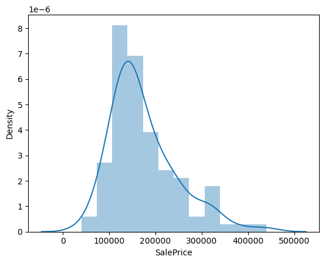

```python
#Plot a distplot of the dependent variable(Sale Price)
sns.distplot(saleprice)
plt.show
print(f"Skew of Saleprice :{saleprice.skew().round(2)}")
```

**The saleprice values are not normally distrivutes has is positively skewed with a value of 1.18**

```
Skew of the log of Saleprice :-0.1
```

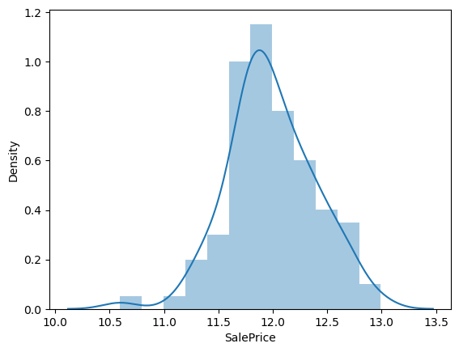

```python
# Plot the distplot of log of saleprice
sns.distplot(np.log(saleprice))
plt.show
print(f"Skew of the log of Saleprice :{np.log(saleprice).skew().round(2)}")
```

```python
#Assigning the log of saleprice to the target variable
target = np.log(saleprice)
```

**After the log transformation of the target variable, the distribution is almost normal with a slight skew of -0.1.**

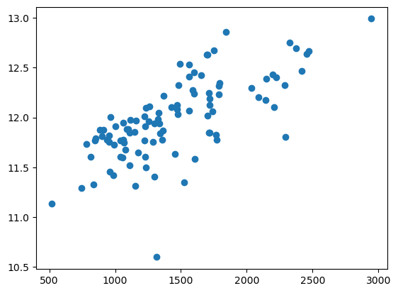

```
Correlation between GrLivArea and target variable:  0.7
```

```python
# Plot a scatterplot of the target variable and the grlivarea
plt.scatter(data['GrLivArea'], y =target)
plt.show()
print("Correlation between GrLivArea and target variable: ",target.corr(data['GrLivArea']).round(2))
```

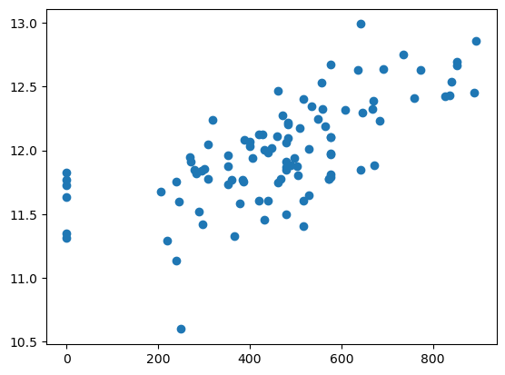

```
Correlation between GarageArea and target variable:  0.69
```

```python
# Plot scatterplot of the target variable and Garage Area
plt.scatter(data['GarageArea'], y =target)
plt.show()
print("Correlation between GarageArea and target variable: ",target.corr(data['GarageArea']).round(2))
```

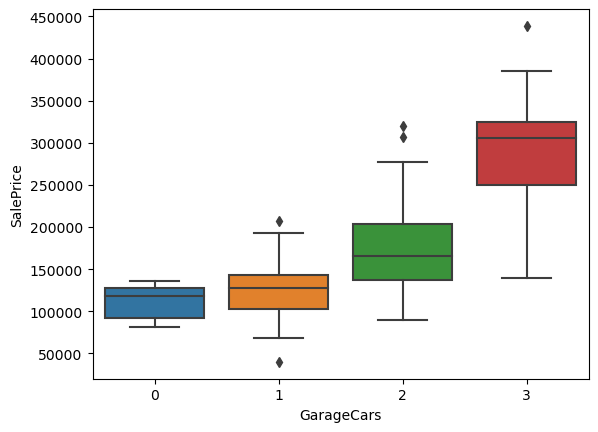

```python
#Plot a Boxplot showing bivariate analysis between SalePrice and Garage Cars
sns.boxplot(data['GarageCars'],data['SalePrice'])
```

**The median saleprice increased with increase in the number of garagecars**

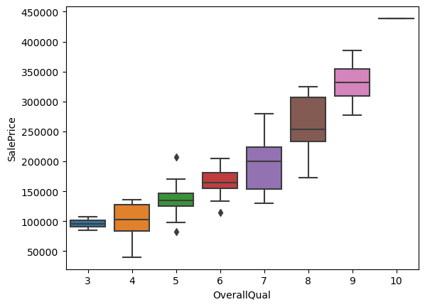

```python
#Plot a Boxplot showing bivariate analysis between SalePrice and OverallQual
sns.boxplot(data['OverallQual'],data['SalePrice'])
```

*The median saleprice increased with increase in the overallqual*

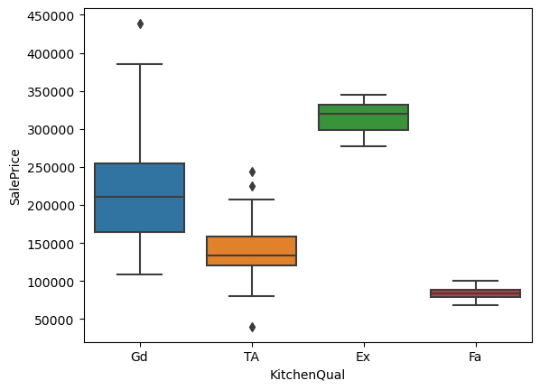

```python
#Plot a Boxplot showing bivariate analysis between SalePrice and KitchenQual
sns.boxplot(data['KitchenQual'],data['SalePrice'])
```

**The median sale price of the houses decreased as the kitchen quality decreased with excellent have the highest mean sale price**

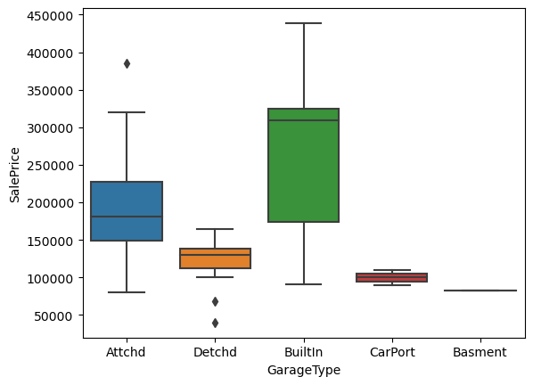

```python
#Plot a Boxplot showing bivariate analysis between SalePrice and GarageType
sns.boxplot(data['GarageType'],data['SalePrice'])
```

**The Builtin Garage type had the highest median saleprice while basement garages had the least.**

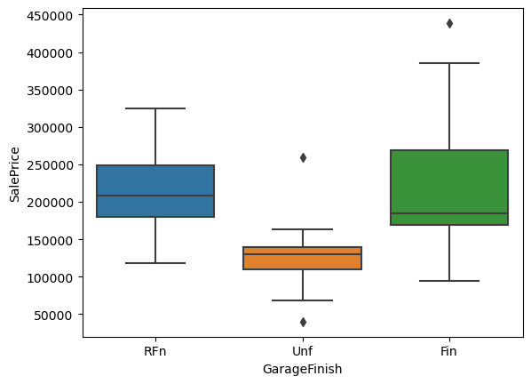

```python
#Plot a Boxplot showing bivariate analysis between SalePrice and GarageFinish
sns.boxplot(data['GarageFinish'],data['SalePrice'])
```

**Unfinished Garages had lower median sale price**

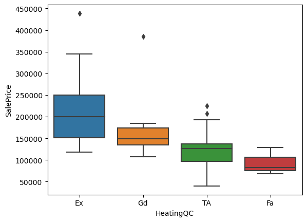

```python
#Plot a Boxplot showing bivariate analysis between SalePrice and HeatingQC
sns.boxplot(data['HeatingQC'],data['SalePrice'])
```

**The median sale price of the houses decreased as the heactingQc quality decreased**.

Back to top

### 2.3 Data Preparation

```python
#Finding the value counts of the KitchenQual variable
data['KitchenQual'].value_counts()
```

```
TA    55
Gd    38
Fa     4
Ex     3
Name: KitchenQual, dtype: int64
```

```python
# Replacing the non numerical values to numerical values
data['KitchenQual'].replace(['Ex','Gd','TA','Fa'],[1,2,3,4],inplace =True)

data['KitchenQual'].value_counts()
```

```
3    55
2    38
4     4
1     3
Name: KitchenQual, dtype: int64
```

```python
#Finding the value counts of the HeatingQC variable
data['HeatingQC'].value_counts()
```

```
Ex    51
TA    27
Gd    19
Fa     3
Name: HeatingQC, dtype: int64
```

```python
# Replacing the non numerical values to numerical values
data['HeatingQC'].replace(['Ex','Gd','TA','Fa'],[1,2,3,4],inplace =True)

data['HeatingQC'].value_counts()
```

```
1    51
3    27
2    19
4     3
Name: HeatingQC, dtype: int64
```

```python
#Finding the value counts of the Garage Finish variable
data['GarageFinish'].value_counts()
```

```
Unf    42
RFn    34
Fin    18
Name: GarageFinish, dtype: int64
```

```python
# Replacing the non numerical values to numerical values
data['GarageFinish'].replace(['Unf','RFn','Fin'],[1,2,3],inplace =True)

data['GarageFinish'].value_counts()
```

```
1.0    42
2.0    34
3.0    18
Name: GarageFinish, dtype: int64
```

```python
#Dropping nulls  from the dataframe
data = data.interpolate().dropna(axis =1)

#Find the shape of the new dataframe
data.shape
```

```
(100, 69)
```

```python
#Assigning the log of saleprice to the target variable
target = np.log(saleprice)

target.describe() # summary statistics of the target variable
```

```
count    100.000000
mean      11.986263
std        0.402132
min       10.596635
25%       11.770372
50%       11.943082
75%       12.244089
max       12.991753
Name: SalePrice, dtype: float64
```

**Log Transformation is one of the methods to transforma dataset to schieve linearity.Log transformation also de-emphasizes outliers and allows us to potentially obtain a bell-shaped distribution. The idea is that taking the log of the data can restore symmetry to the data.**

```python
#Display the top 5 values of the target variable
target.head()
```

```
0    12.247694
1    12.109011
2    12.317167
3    11.849398
4    12.429216
Name: SalePrice, dtype: float64
```

```python
# Selecting the numeric columns
numeric = data.select_dtypes(include =[np.number])

#Check the shape of the numeric columns
numeric.shape
```

```
(100, 42)
```

```python
numeric.info()
```

```
<class 'pandas.core.frame.DataFrame'>
RangeIndex: 100 entries, 0 to 99
Data columns (total 42 columns):
 #   Column         Non-Null Count  Dtype
---  ------         --------------  -----
 0   Unnamed: 0     100 non-null    int64
 1   Id             100 non-null    int64
 2   MSSubClass     100 non-null    int64
 3   LotFrontage    100 non-null    float64
 4   LotArea        100 non-null    int64
 5   OverallQual    100 non-null    int64
 6   OverallCond    100 non-null    int64
 7   YearBuilt      100 non-null    int64
 8   YearRemodAdd   100 non-null    int64
 9   MasVnrArea     100 non-null    float64
```

[output cut: 34 more lines]

Back to top

### 2.4 Correlation

Correlation is a statistical term which in common usage refers to how close two variables are to having a linear relationship with each other. Linear correlation scores are typically a value between -1 and 1 with 0 representing no relationship. Features or variables with high correlation are more linearly dependent and hence have almost the same effect on the dependent variable. So, when two features have high correlation, we can drop one of the two features.

Feature selection is a way to reduce the number of features and hence reduce the computational complexity of the model. Many times feature selection becomes very useful to overcome with overfitting problem. It helps us in determining the smallest set of features that are needed to predict the response variable with high accuracy.

```python
#Finding the correlation between SalePrice and the independent variables

corr = numeric.corr()

corr['SalePrice'].sort_values(ascending=False)
```

```
SalePrice        1.000000
OverallQual      0.855061
GrLivArea        0.735129
GarageArea       0.688249
GarageCars       0.663441
YearBuilt        0.658636
TotalBsmtSF      0.616297
GarageYrBlt      0.589361
GarageFinish     0.582381
FullBath         0.579505
MasVnrArea       0.571836
TotRmsAbvGrd     0.553603
1stFlrSF         0.550912
YearRemodAdd     0.548330
LotArea          0.497124
Fireplaces       0.487907
WoodDeckSF       0.451241
2ndFlrSF         0.381076
BsmtUnfSF        0.327020
HalfBath         0.319304
OpenPorchSF      0.301960
LotFrontage      0.277853
BsmtFinSF1       0.266713
MoSold           0.256863
BedroomAbvGr     0.233426
BsmtFullBath     0.155689
ScreenPorch      0.035930
3SsnPorch       -0.019391
BsmtHalfBath    -0.055100
MSSubClass      -0.066819
MiscVal         -0.134707
BsmtFinSF2      -0.138126
LowQualFinSF    -0.150027
Id              -0.162735
Unnamed: 0      -0.162735
OverallCond     -0.170443
EnclosedPorch   -0.233483
KitchenAbvGr    -0.235659
YrSold          -0.262683
HeatingQC       -0.537435
KitchenQual     -0.683071
PoolArea              NaN
Name: SalePrice, dtype: float64
```

```python
#Choosing the top 20 independent variables positively correlated to the target varible along with top 2 negatively correlated independent variables.
cols = corr['SalePrice'].sort_values(ascending =False)[0:20].append(corr['SalePrice'].sort_values(ascending =False)[-3:-1]).index
cols
```

```
Index(['SalePrice', 'OverallQual', 'GrLivArea', 'GarageArea', 'GarageCars',
       'YearBuilt', 'TotalBsmtSF', 'GarageYrBlt', 'GarageFinish', 'FullBath',
       'MasVnrArea', 'TotRmsAbvGrd', '1stFlrSF', 'YearRemodAdd', 'LotArea',
       'Fireplaces', 'WoodDeckSF', '2ndFlrSF', 'BsmtUnfSF', 'HalfBath',
       'HeatingQC', 'KitchenQual'],
      dtype='object')
```

```python
# Generating the Correlation matrix
data[cols].corr()
```

|  | SalePrice | OverallQual | GrLivArea | GarageArea | GarageCars | YearBuilt | TotalBsmtSF | GarageYrBlt | GarageFinish | FullBath | ... | 1stFlrSF | YearRemodAdd | LotArea | Fireplaces | WoodDeckSF | 2ndFlrSF | BsmtUnfSF | HalfBath | HeatingQC | KitchenQual |
| --- | --- | --- | --- | --- | --- | --- | --- | --- | --- | --- | --- | --- | --- | --- | --- | --- | --- | --- | --- | --- | --- |
| SalePrice | 1.000000 | 0.855061 | 0.735129 | 0.688249 | 0.663441 | 0.658636 | 0.616297 | 0.589361 | 0.582381 | 0.579505 | ... | 0.550912 | 0.548330 | 0.497124 | 0.487907 | 0.451241 | 0.381076 | 0.327020 | 0.319304 | -0.537435 | -0.683071 |
| OverallQual | 0.855061 | 1.000000 | 0.673248 | 0.713936 | 0.727775 | 0.579579 | 0.516214 | 0.598188 | 0.545838 | 0.600099 | ... | 0.455971 | 0.493440 | 0.341133 | 0.484827 | 0.336132 | 0.390617 | 0.368601 | 0.248292 | -0.566466 | -0.690203 |
| GrLivArea | 0.735129 | 0.673248 | 1.000000 | 0.489721 | 0.483806 | 0.351286 | 0.443919 | 0.337760 | 0.505275 | 0.707629 | ... | 0.466063 | 0.322117 | 0.344181 | 0.516102 | 0.252817 | 0.715242 | 0.333004 | 0.397435 | -0.344055 | -0.437934 |
| GarageArea | 0.688249 | 0.713936 | 0.489721 | 1.000000 | 0.921886 | 0.503821 | 0.377216 | 0.550912 | 0.345834 | 0.367732 | ... | 0.333798 | 0.396217 | 0.382192 | 0.317951 | 0.303619 | 0.290965 | 0.200368 | 0.244121 | -0.441707 | -0.578165 |
| GarageCars | 0.663441 | 0.727775 | 0.483806 | 0.921886 | 1.000000 | 0.486107 | 0.308516 | 0.567272 | 0.375151 | 0.426565 | ... | 0.277287 | 0.430133 | 0.312008 | 0.345812 | 0.230788 | 0.328547 | 0.212663 | 0.227655 | -0.463170 | -0.538351 |
| YearBuilt | 0.658636 | 0.579579 | 0.351286 | 0.503821 | 0.486107 | 1.000000 | 0.408568 | 0.775229 | 0.516329 | 0.480126 | ... | 0.323920 | 0.620173 | 0.188510 | 0.137829 | 0.273461 | 0.157514 | 0.211070 | 0.380599 | -0.534342 | -0.621998 |
| TotalBsmtSF | 0.616297 | 0.516214 | 0.443919 | 0.377216 | 0.308516 | 0.408568 | 1.000000 | 0.299449 | 0.359496 | 0.226715 | ... | 0.814766 | 0.342116 | 0.401550 | 0.408234 | 0.354841 | -0.156781 | 0.417320 | -0.023435 | -0.376563 | -0.418177 |
| GarageYrBlt | 0.589361 | 0.598188 | 0.337760 | 0.550912 | 0.567272 | 0.775229 | 0.299449 | 1.000000 | 0.422521 | 0.436647 | ... | 0.184054 | 0.672650 | 0.127404 | 0.067773 | 0.209514 | 0.211245 | 0.268328 | 0.315861 | -0.521873 | -0.594709 |
| GarageFinish | 0.582381 | 0.545838 | 0.505275 | 0.345834 | 0.375151 | 0.516329 | 0.359496 | 0.422521 | 1.000000 | 0.513479 | ... | 0.299150 | 0.308727 | 0.299152 | 0.449610 | 0.224908 | 0.318677 | 0.077561 | 0.258492 | -0.320843 | -0.328196 |
| FullBath | 0.579505 | 0.600099 | 0.707629 | 0.367732 | 0.426565 | 0.480126 | 0.226715 | 0.436647 | 0.513479 | 1.000000 | ... | 0.245339 | 0.377910 | -0.070324 | 0.310177 | 0.010882 | 0.588276 | 0.407100 | 0.158078 | -0.411084 | -0.389593 |
| MasVnrArea | 0.571836 | 0.530543 | 0.549756 | 0.398683 | 0.396203 | 0.376098 | 0.481571 | 0.313994 | 0.509335 | 0.493868 | ... | 0.464130 | 0.267697 | 0.094462 | 0.365398 | 0.230396 | 0.239393 | 0.256385 | 0.132722 | -0.308233 | -0.319994 |
| TotRmsAbvGrd | 0.553603 | 0.550755 | 0.831927 | 0.375378 | 0.373383 | 0.214259 | 0.286980 | 0.259297 | 0.316414 | 0.741525 | ... | 0.288547 | 0.255801 | 0.110162 | 0.370838 | 0.122738 | 0.674559 | 0.380573 | 0.217834 | -0.297345 | -0.358148 |
| 1stFlrSF | 0.550912 | 0.455971 | 0.466063 | 0.333798 | 0.277287 | 0.323920 | 0.814766 | 0.184054 | 0.299150 | 0.245339 | ... | 1.000000 | 0.167113 | 0.415764 | 0.432826 | 0.303461 | -0.272002 | 0.300808 | -0.109606 | -0.207771 | -0.334898 |
| YearRemodAdd | 0.548330 | 0.493440 | 0.322117 | 0.396217 | 0.430133 | 0.620173 | 0.342116 | 0.672650 | 0.308727 | 0.377910 | ... | 0.167113 | 1.000000 | 0.120216 | 0.009406 | 0.197462 | 0.230655 | 0.221494 | 0.253356 | -0.515867 | -0.562348 |
| LotArea | 0.497124 | 0.341133 | 0.344181 | 0.382192 | 0.312008 | 0.188510 | 0.401550 | 0.127404 | 0.299152 | -0.070324 | ... | 0.415764 | 0.120216 | 1.000000 | 0.255125 | 0.520432 | 0.054185 | 0.022300 | 0.286847 | -0.070450 | -0.185333 |
| Fireplaces | 0.487907 | 0.484827 | 0.516102 | 0.317951 | 0.345812 | 0.137829 | 0.408234 | 0.067773 | 0.449610 | 0.310177 | ... | 0.432826 | 0.009406 | 0.255125 | 1.000000 | 0.247786 | 0.219996 | 0.096548 | 0.104475 | -0.231662 | -0.228855 |
| WoodDeckSF | 0.451241 | 0.336132 | 0.252817 | 0.303619 | 0.230788 | 0.273461 | 0.354841 | 0.209514 | 0.224908 | 0.010882 | ... | 0.303461 | 0.197462 | 0.520432 | 0.247786 | 1.000000 | 0.040801 | -0.051542 | 0.214371 | -0.114662 | -0.254901 |
| 2ndFlrSF | 0.381076 | 0.390617 | 0.715242 | 0.290965 | 0.328547 | 0.157514 | -0.156781 | 0.211245 | 0.318677 | 0.588276 | ... | -0.272002 | 0.230655 | 0.054185 | 0.219996 | 0.040801 | 1.000000 | 0.105725 | 0.529099 | -0.233227 | -0.241187 |
| BsmtUnfSF | 0.327020 | 0.368601 | 0.333004 | 0.200368 | 0.212663 | 0.211070 | 0.417320 | 0.268328 | 0.077561 | 0.407100 | ... | 0.300808 | 0.221494 | 0.022300 | 0.096548 | -0.051542 | 0.105725 | 1.000000 | 0.042635 | -0.191478 | -0.236214 |
| HalfBath | 0.319304 | 0.248292 | 0.397435 | 0.244121 | 0.227655 | 0.380599 | -0.023435 | 0.315861 | 0.258492 | 0.158078 | ... | -0.109606 | 0.253356 | 0.286847 | 0.104475 | 0.214371 | 0.529099 | 0.042635 | 1.000000 | -0.235673 | -0.285163 |
| HeatingQC | -0.537435 | -0.566466 | -0.344055 | -0.441707 | -0.463170 | -0.534342 | -0.376563 | -0.521873 | -0.320843 | -0.411084 | ... | -0.207771 | -0.515867 | -0.070450 | -0.231662 | -0.114662 | -0.233227 | -0.191478 | -0.235673 | 1.000000 | 0.536413 |
| KitchenQual | -0.683071 | -0.690203 | -0.437934 | -0.578165 | -0.538351 | -0.621998 | -0.418177 | -0.594709 | -0.328196 | -0.389593 | ... | -0.334898 | -0.562348 | -0.185333 | -0.228855 | -0.254901 | -0.241187 | -0.236214 | -0.285163 | 0.536413 | 1.000000 |

22 rows × 22 columns

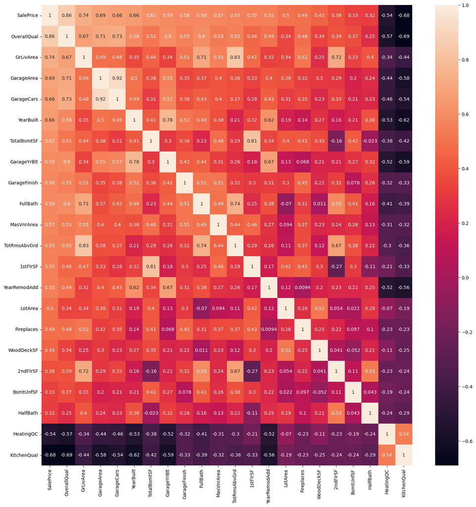

```python
# Ploting the a heatmap for the correlation matrix
plt.figure(figsize=(18, 18))
sns.heatmap(data[cols].corr(),annot =True)
```

**Independent varaibles showing high correlaton to each other**

- YearBuilt & GarageYrBlt.
- TotalBsmtSF & 1stFlrSF.
- GrLivArea & TotRmsAbvGrd.
- GarageArea & GarageCars.  
  **one of these variables have to be eliminated**

Back to top

## 3. Project Description

Linear regression model with 17 variables( which were both postively and negatively highly correlated to the target variable) was the model that had the best performance. The testing data had a R-squared score of 86% which was vaery close to the R-squared score of 89% on the training data. The model has generalised on the data and shows little overfitting as it has similar results on both training & testing datasets. The features or variables chosen are OverallQual, GrLivArea, GarageArea, YearBuilt,TotalBsmtSF, GarageFinish, FullBath, MasVnrArea, YearRemodAdd, LotArea, Fireplaces, WoodDeckSF, 2ndFlrSF, BsmtUnfS,HalfBath, HeatingQC, KitchenQual.'GarageCars','GarageYrBlt','1stFlrSF','TotRmsAbvGrd' variables were eliminated even though they had high correlation with the dependent variable as these exhibited multicolinearity or high correlation with another independent variable.

Back to top

### 3.1 Linear Regression

Linear regression is a supervised machine learning algorithm that is used to predict values within a continuous range (i.e., stocks’ price and height) rather than classifying them into categories (i.e., male or female). The values that you want to predict are the dependent variable(s). The predictions can be made using one or more independent variables.

Linear regression is a linear approach for modelling the relationship between a scalar response and one or more explanatory variables (also known as dependent and independent variables). The case of one explanatory variable is called simple linear regression; for more than one, the process is called multiple linear regression.This term is distinct from multivariate linear regression, where multiple correlated dependent variables are predicted, rather than a single scalar variable.

**Mathematically the relationship can be represented with the help of following equation −

#### Y = mX + b

Here, Y is the dependent variable we are trying to predict

**X is the dependent variable we are using to make predictions.**

**m is the slop of the regression line which represents the effect X has on Y**

**b is a constant, known as the Y-intercept. If X = 0,Y would be equal to b.*

A linear relationship will be called positive if both independent and dependent variable increases.

A linear relationship will be called positive if independent increases and dependent variable decreases.

Linear regression is of the following two types −

Simple Linear Regression - which predicts a response using a single feature. The assumption in SLR is that the two variables are linearly related.

Python implementation We can implement linear regression in Python by using importing liner_model from sklearn library.

Python implementation example

lr = linear_model.LinearRegression()

Next, train the model using the training sets as follows −

lr.fit(X_train, y_train)

Next, make predictions using the testing set as follows −

y_pred = regr.predict(X_test)

Multiple linear regression can be viewed as a natural extension of simple linear regression. The main difference is that now multiple sets of data are used to make the prediction.

Therefore, the equation for multiple linear regression becomes:

#### Y = m1X1 +m2X2 +m3x3.....+mnxn+ b

where x1, x2....xn represent the data points of all the independent variables used to make the prediction,m1,m2....,mn are the weights, and b is the bias.

**Assumptions**

The following are some assumptions about dataset that is made by Linear Regression model −

Multi-collinearity − Linear regression model assumes that there is very little or no multi-collinearity in the data. Basically, multi-collinearity occurs when the independent variables or features have dependency in them.

Auto-correlation − Another assumption Linear regression model assumes is that there is very little or no auto-correlation in the data. Basically, auto-correlation occurs when there is dependency between residual errors.

Relationship between variables − Linear regression model assumes that the relationship between response and feature variables must be linear.

Back to top

### 3.2 Analysis

### MODEL 1

```python
# Choosing the variables for model 1 - first 3 Variables that are most positively correlated and 2 variables that are most negatively correlated to Saleprice
cols1 = corr['SalePrice'].sort_values(ascending =False)[0:4].append(corr['SalePrice'].sort_values(ascending =False)[-3:-1]).index
cols1
```

```
Index(['SalePrice', 'OverallQual', 'GrLivArea', 'GarageArea', 'HeatingQC',
       'KitchenQual'],
      dtype='object')
```

```python
#Filtering the dataframe
X1 = numeric[cols1]

#Using the log of the sale price as the target variable
Y_train =target

# Deleting the target variable from the data
X1_train = X1.drop(['SalePrice'],axis =1)
```

```python
lr = linear_model.LinearRegression()

model_1 =lr.fit(X1_train,Y_train)

predictions1 = model_1.predict(X1_train)

print("R^2 value of model_1 :",model_1.score (X1_train,Y_train))
```

```
R^2 value of model_1 : 0.7927169243916721
```

```
Skew :0.34
```

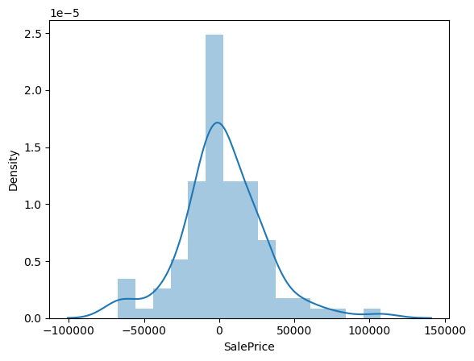

```python
#Plotting the distribution plot of saleprice - saleprice predictions
sns.distplot(np.exp(Y_train) -  np.exp(predictions1))
print(f"Skew :{(np.exp(Y_train) -  np.exp(predictions1)).skew().round(2)}")
```

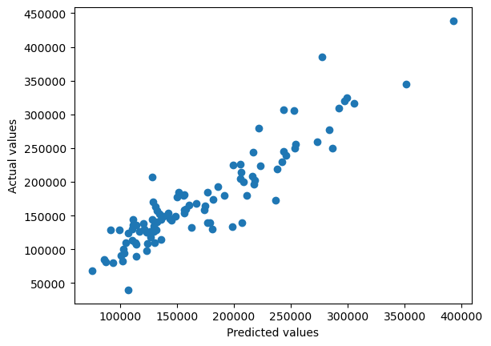

```python
#Plot the scatterplot
plt.scatter(np.exp(predictions1),np.exp(Y_train))
plt.ylabel('Actual values')
plt.xlabel('Predicted values')
```

### MODEL 2

```python
# Choosing the variables for model 2-
cols2 = corr['SalePrice'].sort_values(ascending =False)[0:6].append(corr['SalePrice'].sort_values(ascending =False)[-3:-1]).index
print(cols2)

#Filtering the dataframe based on the variables chosen
X2 = numeric[cols2]
print(X2.head())

#Using the log of the sale price as the target variable
Y_train =target

#Dropping the target variable and the one of the multicolinear independent variable
X2_train = X2.drop(['SalePrice','GarageCars'],axis =1)

lr = linear_model.LinearRegression()
model_2 =lr.fit(X2_train,Y_train)
predictions2 = model_2.predict(X2_train)

print("R^2 value of model_ 2:",model_2.score (X2_train,Y_train))
```

```
Index(['SalePrice', 'OverallQual', 'GrLivArea', 'GarageArea', 'GarageCars',
       'YearBuilt', 'HeatingQC', 'KitchenQual'],
      dtype='object')
   SalePrice  OverallQual  GrLivArea  GarageArea  GarageCars  YearBuilt  \
0     208500            7       1710         548           2       2003
1     181500            6       1262         460           2       1976
2     223500            7       1786         608           2       2001
3     140000            7       1717         642           3       1915
4     250000            8       2198         836           3       2000

   HeatingQC  KitchenQual
0          1            2
1          1            3
2          1            2
3          2            2
4          1            2
R^2 value of model_ 2: 0.8302565468699618
```

```
Skew :1.04
```

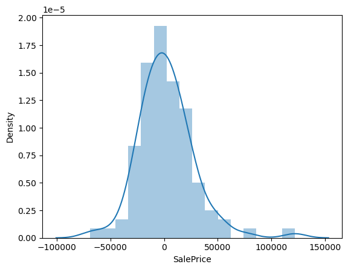

```python
#Plotting the distribution plot of saleprice - saleprice predictions
sns.distplot(np.exp(Y_train) -  np.exp(predictions2))
print(f"Skew :{(np.exp(Y_train) -  np.exp(predictions2)).skew().round(2)}")
```

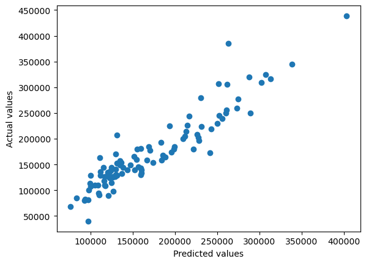

```python
#Plot the scatterplot
plt.scatter(np.exp(predictions2),np.exp(Y_train))
plt.ylabel('Actual values')
plt.xlabel('Predicted values')
```

### Model 3

```python
# Choosing the variables for model 3
cols3 = corr['SalePrice'].sort_values(ascending = False)[0:7].append(corr['SalePrice'].sort_values(ascending =False)[-3:-1]).index
print(cols3)

X3 = numeric[cols3]
print(X3.head())

Y_train =target
#Dropping the target variable and the one of the multicolinear independent variable
X3_train = X3.drop(['SalePrice','GarageCars'],axis =1)

lr = linear_model.LinearRegression()
model_3 =lr.fit(X3_train,Y_train)

predictions3 = model_3.predict(X3_train)

print("R^2 value of model_3 :",model_3.score (X3_train,Y_train))
```

```
Index(['SalePrice', 'OverallQual', 'GrLivArea', 'GarageArea', 'GarageCars',
       'YearBuilt', 'TotalBsmtSF', 'HeatingQC', 'KitchenQual'],
      dtype='object')
   SalePrice  OverallQual  GrLivArea  GarageArea  GarageCars  YearBuilt  \
0     208500            7       1710         548           2       2003
1     181500            6       1262         460           2       1976
2     223500            7       1786         608           2       2001
3     140000            7       1717         642           3       1915
4     250000            8       2198         836           3       2000

   TotalBsmtSF  HeatingQC  KitchenQual
0          856          1            2
1         1262          1            3
2          920          1            2
3          756          2            2
4         1145          1            2
R^2 value of model_3 : 0.8571758050861773
```

```
Skew :0.47
```

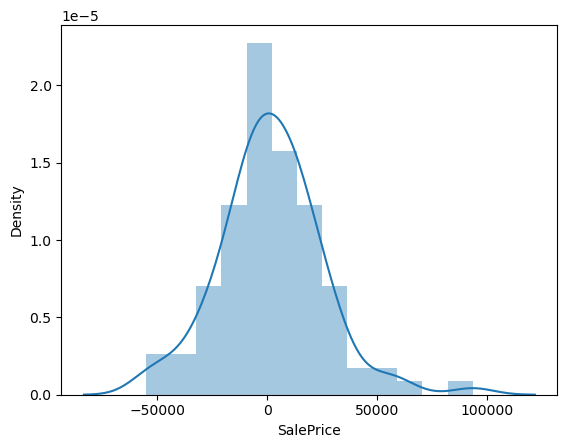

```python
#Plotting the distribution plot of saleprice - saleprice predictions
sns.distplot(np.exp(Y_train) -  np.exp(predictions3))
print(f"Skew :{(np.exp(Y_train) -  np.exp(predictions3)).skew().round(2)}")
```

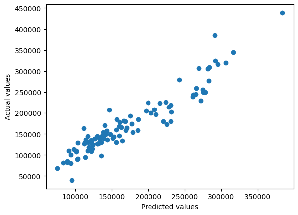

```python
#Plot the scatterplot
plt.scatter(np.exp(predictions3),np.exp(Y_train))
plt.ylabel('Actual values')
plt.xlabel('Predicted values')
```

### Model 4

```python
cols4 = corr['SalePrice'].sort_values(ascending =False)[0:10].append(corr['SalePrice'].sort_values(ascending =False)[-3:-1]).index
print(cols4)

X4 = numeric[cols4]
print(X4.head())

Y_train =target

#Dropping the target variable and the one of the multicolinear independent variable
X4_train = X4.drop(['SalePrice','GarageCars','GarageYrBlt'],axis =1)

lr = linear_model.LinearRegression()
model_4 =lr.fit(X4_train,Y_train)
predictions4 = model_4.predict(X4_train)

print("R^2 value of model_4 :",model_4.score (X4_train,Y_train))
```

```
Index(['SalePrice', 'OverallQual', 'GrLivArea', 'GarageArea', 'GarageCars',
       'YearBuilt', 'TotalBsmtSF', 'GarageYrBlt', 'GarageFinish', 'FullBath',
       'HeatingQC', 'KitchenQual'],
      dtype='object')
   SalePrice  OverallQual  GrLivArea  GarageArea  GarageCars  YearBuilt  \
0     208500            7       1710         548           2       2003
1     181500            6       1262         460           2       1976
2     223500            7       1786         608           2       2001
3     140000            7       1717         642           3       1915
4     250000            8       2198         836           3       2000

   TotalBsmtSF  GarageYrBlt  GarageFinish  FullBath  HeatingQC  KitchenQual
0          856       2003.0           2.0         2          1            2
1         1262       1976.0           2.0         2          1            3
2          920       2001.0           2.0         2          1            2
3          756       1998.0           1.0         1          2            2
4         1145       2000.0           2.0         2          1            2
R^2 value of model_4 : 0.8613561418912532
```

```
Skew :0.14
```

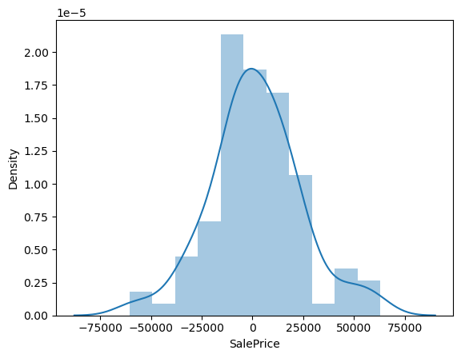

```python
#Plotting the distribution plot of saleprice - saleprice predictions
sns.distplot(np.exp(Y_train) -  np.exp(predictions4))
print(f"Skew :{(np.exp(Y_train) -  np.exp(predictions4)).skew().round(2)}")
```

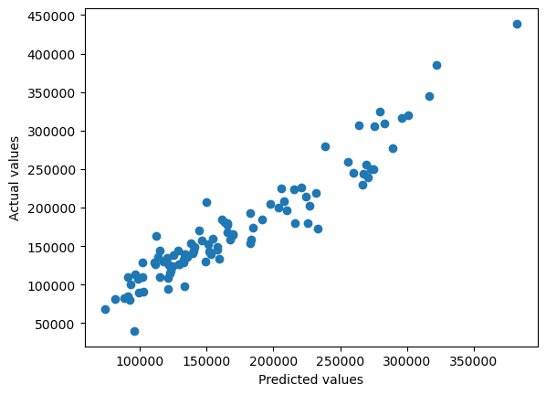

```python
#Plot the scatterplot
plt.scatter(np.exp(predictions4),np.exp(Y_train))
plt.ylabel('Actual values')
plt.xlabel('Predicted values')
```

### Model 5

```python
cols5 = list(corr["SalePrice"][(corr["SalePrice"]>0.5) | (corr["SalePrice"]<-0.5)].index)
cols5
print(cols5)

X5 = numeric[cols5]
print(X5.head())

Y_train =target

#Dropping the target variable and the one of the multicolinear independent variable
X5_train = X5.drop(['SalePrice','TotRmsAbvGrd','GarageCars','GarageYrBlt','1stFlrSF'],axis =1)

lr = linear_model.LinearRegression()
model_5 =lr.fit(X5_train,Y_train)
predictions5 = model_5.predict(X5_train)

print("R^2 value of model_5 :",model_5.score (X5_train,Y_train))
```

```
['OverallQual', 'YearBuilt', 'YearRemodAdd', 'MasVnrArea', 'TotalBsmtSF', 'HeatingQC', '1stFlrSF', 'GrLivArea', 'FullBath', 'KitchenQual', 'TotRmsAbvGrd', 'GarageYrBlt', 'GarageFinish', 'GarageCars', 'GarageArea', 'SalePrice']
   OverallQual  YearBuilt  YearRemodAdd  MasVnrArea  TotalBsmtSF  HeatingQC  \
0            7       2003          2003       196.0          856          1
1            6       1976          1976         0.0         1262          1
2            7       2001          2002       162.0          920          1
3            7       1915          1970         0.0          756          2
4            8       2000          2000       350.0         1145          1

   1stFlrSF  GrLivArea  FullBath  KitchenQual  TotRmsAbvGrd  GarageYrBlt  \
0       856       1710         2            2             8       2003.0
1      1262       1262         2            3             6       1976.0
2       920       1786         2            2             6       2001.0
3       961       1717         1            2             7       1998.0
4      1145       2198         2            2             9       2000.0

   GarageFinish  GarageCars  GarageArea  SalePrice
0           2.0           2         548     208500
1           2.0           2         460     181500
2           2.0           2         608     223500
3           1.0           3         642     140000
4           2.0           3         836     250000
R^2 value of model_5 : 0.8655434105058908
```

```
Skew :0.05
```

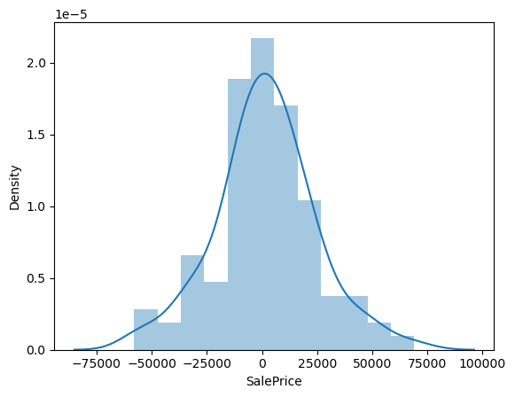

```python
#Plotting the distribution plot of saleprice - saleprice predictions
sns.distplot(np.exp(Y_train) -  np.exp(predictions5))
print(f"Skew :{(np.exp(Y_train) -  np.exp(predictions5)).skew().round(2)}")
```

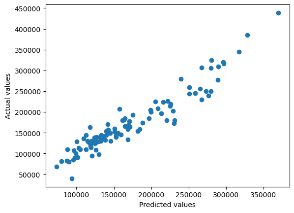

```python
#Plot the scatterplot
plt.scatter(np.exp(predictions5),np.exp(Y_train))
plt.ylabel('Actual values')
plt.xlabel('Predicted values')
```

### Model 6

```python
cols6 = corr['SalePrice'].sort_values(ascending =False)[0:20].append(corr['SalePrice'].sort_values(ascending =False)[-3:-1]).index
print(cols6)

X6 = numeric[cols6]
print(X6.head())

Y_train =target

#Dropping the target variable and the one of the multicolinear independent variable
X6_train = X6.drop(['SalePrice','GarageCars','GarageYrBlt','1stFlrSF','TotRmsAbvGrd'],axis =1)

lr = linear_model.LinearRegression()
model_6 =lr.fit(X6_train,Y_train)
predictions6 = model_6.predict(X6_train)

print("R^2 value of model_6 :",model_6.score (X6_train,Y_train))
```

```
Index(['SalePrice', 'OverallQual', 'GrLivArea', 'GarageArea', 'GarageCars',
       'YearBuilt', 'TotalBsmtSF', 'GarageYrBlt', 'GarageFinish', 'FullBath',
       'MasVnrArea', 'TotRmsAbvGrd', '1stFlrSF', 'YearRemodAdd', 'LotArea',
       'Fireplaces', 'WoodDeckSF', '2ndFlrSF', 'BsmtUnfSF', 'HalfBath',
       'HeatingQC', 'KitchenQual'],
      dtype='object')
   SalePrice  OverallQual  GrLivArea  GarageArea  GarageCars  YearBuilt  \
0     208500            7       1710         548           2       2003
1     181500            6       1262         460           2       1976
2     223500            7       1786         608           2       2001
3     140000            7       1717         642           3       1915
4     250000            8       2198         836           3       2000

   TotalBsmtSF  GarageYrBlt  GarageFinish  FullBath  ...  1stFlrSF  \
0          856       2003.0           2.0         2  ...       856
1         1262       1976.0           2.0         2  ...      1262
2          920       2001.0           2.0         2  ...       920
3          756       1998.0           1.0         1  ...       961
4         1145       2000.0           2.0         2  ...      1145

   YearRemodAdd  LotArea  Fireplaces  WoodDeckSF  2ndFlrSF  BsmtUnfSF  \
0          2003     8450           0           0       854        150
1          1976     9600           1         298         0        284
2          2002    11250           1           0       866        434
3          1970     9550           1           0       756        540
4          2000    14260           1         192      1053        490

   HalfBath  HeatingQC  KitchenQual
0         1          1            2
1         0          1            3
2         1          1            2
3         0          2            2
4         1          1            2

[5 rows x 22 columns]
R^2 value of model_6 : 0.8867899238023222
```

```
Skew :0.33
```

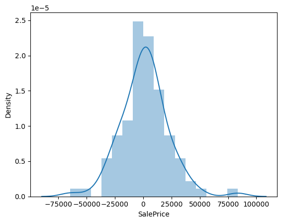

```python
#Plotting the distribution plot of saleprice - saleprice predictions
sns.distplot(np.exp(Y_train) -  np.exp(predictions6))
print(f"Skew :{(np.exp(Y_train) -  np.exp(predictions6)).skew().round(2)}")
```

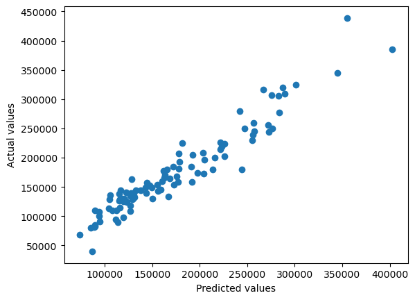

```python
#Plot the scatterplot
plt.scatter(np.exp(predictions6),np.exp(Y_train))
plt.ylabel('Actual values')
plt.xlabel('Predicted values')
```

**The scatterplot of the sale price to sale price predictions is a straight line and closely fit

Back to top

### 3.3 Results

Model_6 with 17 variables has the best performance. The R squared score is 0.89. The model explains 88.67% of the fitted data. R-Squared (R² or the coefficient of determination) is a statistical measure in a regression model that determines the proportion of variance in the dependent variable that can be explained by the independent variable. In other words, r-squared shows how well the data fit the regression model (the goodness of fit). The higher the R-squared, the better the model fits your data. The histogram plot of (sale price - saleprice predcitions) is a normal distribution and the scatter plot of the sale price to sale precitions is a straight line.

Back to top

### 3.4 Verify Your Model Against Test Data

**Verifying the model against test data involves transforming the test data using the same steps/processes used for the training data like categorical value transformation, log transformation, treating null values before predicting the test values.**

```python
# Import the test data
hsd_test = pd.read_csv('jtest.csv')

#Create a copy of the imported test data
testdata = hsd_test.copy()

#Check the shape of the test data
testdata.shape
```

```
(100, 82)
```

```python
testdata.head()
```

|  | Unnamed: 0 | Id | MSSubClass | MSZoning | LotFrontage | LotArea | Street | Alley | LotShape | LandContour | ... | PoolArea | PoolQC | Fence | MiscFeature | MiscVal | MoSold | YrSold | SaleType | SaleCondition | SalePrice |
| --- | --- | --- | --- | --- | --- | --- | --- | --- | --- | --- | --- | --- | --- | --- | --- | --- | --- | --- | --- | --- | --- |
| 0 | 100 | 101 | 20 | RL | NaN | 10603 | Pave | NaN | IR1 | Lvl | ... | 0 | NaN | NaN | NaN | 0 | 2 | 2010 | WD | Normal | 205000 |
| 1 | 101 | 102 | 60 | RL | 77.0 | 9206 | Pave | NaN | Reg | Lvl | ... | 0 | NaN | NaN | NaN | 0 | 6 | 2010 | WD | Normal | 178000 |
| 2 | 102 | 103 | 90 | RL | 64.0 | 7018 | Pave | NaN | Reg | Bnk | ... | 0 | NaN | NaN | NaN | 0 | 6 | 2009 | WD | Alloca | 118964 |
| 3 | 103 | 104 | 20 | RL | 94.0 | 10402 | Pave | NaN | IR1 | Lvl | ... | 0 | NaN | NaN | NaN | 0 | 5 | 2010 | WD | Normal | 198900 |
| 4 | 104 | 105 | 50 | RM | NaN | 7758 | Pave | NaN | Reg | Lvl | ... | 0 | NaN | NaN | NaN | 0 | 6 | 2007 | WD | Normal | 169500 |

5 rows × 82 columns

### Transforming the test data

```python
# Converting the non numerical data in Kitchenqual, heatingQc,GarageFinish to numerical data
testdata['KitchenQual'].replace(['Ex','Gd','TA','Fa'],[1,2,3,4],inplace =True)
testdata['HeatingQC'].replace(['Ex','Gd','TA','Fa'],[1,2,3,4],inplace =True)
testdata['GarageFinish'].replace(['Unf','RFn','Fin'],[1,2,3],inplace =True)
```

```python
# Checking for nulls
testdata.isnull().sum().sort_values(ascending=False)[0:20]
```

```
MiscFeature     99
PoolQC          99
Alley           97
Fence           76
FireplaceQu     43
LotFrontage     22
GarageType       9
GarageYrBlt      9
GarageFinish     9
GarageQual       9
GarageCond       9
BsmtFinType1     3
BsmtQual         3
BsmtCond         3
BsmtExposure     3
BsmtFinType2     3
KitchenAbvGr     0
Functional       0
BedroomAbvGr     0
HalfBath         0
dtype: int64
```

```python
#Dropping the null values
test = testdata.interpolate().dropna(axis =1)
test.shape
```

```
(100, 68)
```

```python
#Checking the info
test.info()
```

```
<class 'pandas.core.frame.DataFrame'>
RangeIndex: 100 entries, 0 to 99
Data columns (total 68 columns):
 #   Column         Non-Null Count  Dtype
---  ------         --------------  -----
 0   Unnamed: 0     100 non-null    int64
 1   Id             100 non-null    int64
 2   MSSubClass     100 non-null    int64
 3   MSZoning       100 non-null    object
 4   LotArea        100 non-null    int64
 5   Street         100 non-null    object
 6   LotShape       100 non-null    object
 7   LandContour    100 non-null    object
 8   Utilities      100 non-null    object
 9   LotConfig      100 non-null    object
```

[output cut: 60 more lines]

### MODEL 1 TESTING

```python
#Test model_1 on unseen data
X1_test = test[cols1]

Y1_test = np.log(X1_test['SalePrice'])

X1_test = X1_test.drop(['SalePrice'], axis =1)
X1_test
```

|  | OverallQual | GrLivArea | GarageArea | HeatingQC | KitchenQual |
| --- | --- | --- | --- | --- | --- |
| 0 | 6 | 1610 | 480 | 2 | 2 |
| 1 | 6 | 1732 | 476 | 3 | 2 |
| 2 | 5 | 1535 | 410 | 3 | 3 |
| 3 | 7 | 1226 | 740 | 1 | 2 |
| 4 | 7 | 1818 | 240 | 1 | 3 |
| ... | ... | ... | ... | ... | ... |
| 95 | 6 | 1456 | 440 | 3 | 3 |
| 96 | 7 | 1726 | 786 | 1 | 1 |
| 97 | 8 | 3112 | 795 | 2 | 2 |
| 98 | 6 | 2229 | 0 | 1 | 3 |
| 99 | 8 | 1713 | 856 | 1 | 1 |

100 rows × 5 columns

```python
predictions = model_1.predict(X1_test)
print("R-squared value of model_1 test:",model_1.score (X1_test,Y1_test))
```

```
R-squared value of model_1 test: 0.7827239630949745
```

### MODEL 2 Testing

```python
X2_test = test[cols2]

Y2_test = np.log(X2_test['SalePrice'])

#Dropping the target variable and the one of the multicolinear independent variable
X2_test = X2_test.drop(['SalePrice','GarageCars'], axis =1)

predictions = model_2.predict(X2_test)

print("R-squared value of model_2 test:",model_2.score (X2_test,Y2_test))
```

```
R-squared value of model_2 test: 0.7857728785602411
```

### MODEL 3 Testing

```python
X3_test = test[cols3]

Y3_test = np.log(X3_test['SalePrice'])

#Dropping the target variable and the one of the multicolinear independent variable
X3_test = X3_test.drop(['SalePrice','GarageCars'], axis =1)

predictions = model_3.predict(X3_test)

print("R-squared value of model_3 test :",model_3.score (X3_test,Y3_test))
```

```
R-squared value of model_3 test : 0.8035623818909714
```

### MODEL 4 Testing

```python
X4_test = test[cols4]

Y4_test = np.log(X4_test['SalePrice'])

#Dropping the target variable and the one of the multicolinear independent variable
X4_test = X4_test.drop(['SalePrice','GarageCars','GarageYrBlt'], axis =1)

predictions = model_4.predict(X4_test)

print("R-squared value of model_4 test:",model_4.score (X4_test,Y4_test))
```

```
R-squared value of model_4 test: 0.8094815556052675
```

### MODEL 5 Testing

```python
X5_test = test[cols5]

Y5_test = np.log(X5_test['SalePrice'])

#Dropping the target variable and the one of the multicolinear independent variable
X5_test = X5_test.drop(['SalePrice','TotRmsAbvGrd','GarageCars','GarageYrBlt','1stFlrSF'], axis =1)

predictions = model_5.predict(X5_test)

print("R-squared value of model_5 test :",model_5.score (X5_test,Y5_test))
```

```
R-squared value of model_5 test : 0.8137753278359937
```

### MODEL 6 Testing

```python
X6_test = test[cols6]

Y6_test = np.log(X6_test['SalePrice'])

X6_test = X6_test.drop(['SalePrice','GarageCars','GarageYrBlt','1stFlrSF','TotRmsAbvGrd'], axis =1)

predictions = model_6.predict(X6_test)

print("R^2 value of model_6 test :",model_6.score (X6_test,Y6_test))
```

```
R^2 value of model_6 test : 0.8618427683135784
```

```python
#Creating a dataframe with the train & test R-squared scores for each model

results ={'Training_score':[model_1.score(X1_train,Y_train).round(2),model_2.score(X2_train,Y_train).round(2),model_3.score(X3_train,Y_train).round(2),model_4.score(X4_train,Y_train).round(2),model_5.score(X5_train,Y_train).round(2),model_6.score(X6_train,Y_train).round(2)],


'Testing_score':[model_1.score(X1_test,Y1_test).round(2),model_2.score (X2_test,Y2_test).round(2),model_3.score (X3_test,Y3_test).round(2),model_4.score (X4_test,Y4_test).round(2),model_5.score (X5_test,Y5_test).round(2),model_6.score (X6_test,Y6_test).round(2)]}

model = ['model_1','model_2','model_3','model_4','model_5','model_6']

results = pd.DataFrame(results,index =model)

results
```

|  | Training_score | Testing_score |
| --- | --- | --- |
| model_1 | 0.79 | 0.78 |
| model_2 | 0.83 | 0.79 |
| model_3 | 0.86 | 0.80 |
| model_4 | 0.86 | 0.81 |
| model_5 | 0.87 | 0.81 |
| model_6 | 0.89 | 0.86 |

**model_6 has the best results with very close results on the training & testing dataset.The R square values are 0.89 and 0.86 which suggests the model has generalised on the dataset and hence avoiding overfitting.**

Back to top

## Conclusion

The best model that provides the best R-square value for both the training and testing dataset is model_6. The model_6 uses 17 variables. The variables/features are OverallQual, GrLivArea, GarageArea, YearBuilt,TotalBsmtSF, GarageFinish, FullBath, MasVnrArea, YearRemodAdd, LotArea, Fireplaces, WoodDeckSF, 2ndFlrSF, BsmtUnfS,HalfBath, HeatingQC, KitchenQual. Incorporation of the variables that are highly negatively correlated to the target variable along with highly positively correlated ones was able to provide us a model with similar R square scores on both the training and testing dataset.

Back to top

## References

-https://en.wikipedia.org/wiki/Linear_regression 2022.

-https://www.geeksforgeeks.org/linear-regression-python-implementation/ 2022.

- Dotdash Meredith, 2022.https://www.investopedia.com/terms/m/multicollinearity.asp

-Log Transformation. https://www.sciencedirect.com/topics/computer-science/log-transformation

-Leigh Metcalf, William Casey. "4.6 Log Transformation"."Introduction to data analysis".2016

https://www.tutorialspoint.com/machine_learning_with_python/regression_algorithms_linear_regression.htm 2022.